# ESPM 137, Lab 9: Spatial Regression Analysis

#! This lab is worth 10 pts and is due at 5pm on Friday, 10/30 !#

## Overview and Goals

In this lab, we will perform sophisticated statistical regression analyses on GIS data layers to quantify the variables that contribute to tree species richness and reptile species richness across the U.S. We will perform both global (with and without spatial structure) and local spatial regression analyses and compare their results. View the lab intro video to learn more about these analysis methods.

Goals– 1: To learn how to perform spatial regression analysis on GIS data. 2: To learn how to interpret the output of spatial regression analysis. 3: To compare regression methods that include spatial structure to those that do not.

### Set up the R session

Load required packages…

## Part 1: Changing Raster Projection and Resolution

Read in rasters of temperature, precipitation, tree species richness, and reptile species richness…

```r
temp <- raster("temp.tif")
precip <- raster("precip.tif")
Trees <- raster("Trees.tif")
Reptiles <- raster("Reptiles.tif")
```

Now let’s plot the four rasters…

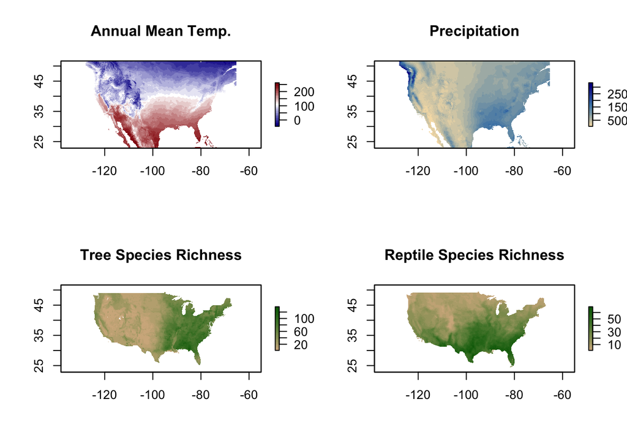

```r
# First create some color schemes, for the sake of variety
BlueRed <- colorRampPalette(c("darkblue", "white", "darkred"))
TanGreen <- colorRampPalette(c("tan", "darkgreen"))
TanBlue <- colorRampPalette(c("wheat", "steelblue", "darkblue"))

# Plot the four rasters
par(mfrow=c(2,2))
plot(temp, col=BlueRed(25), main="Annual Mean Temp.")
plot(precip, col=TanBlue(25), main="Precipitation")
plot(Trees, col=TanGreen(25), main="Tree Species Richness")
plot(Reptiles, col=TanGreen(25), main="Reptile Species Richness")
```

Let’s also read in a shapefile with state borders…

```r
states <- readOGR("states", layer = "states")
states
```

```
## class       : SpatialPolygonsDataFrame
## features    : 51
## extent      : -178.2176, -66.96927, 18.92179, 71.40624  (xmin, xmax, ymin, ymax)
## crs         : +proj=longlat +datum=NAD83 +no_defs
## variables   : 5
## names       : STATE_NAME, DRAWSEQ, STATE_FIPS,         SUB_REGION, STATE_ABBR
## min values  :    Alabama,       1,         01, East North Central,         AK
## max values  :    Wyoming,      51,         56, West South Central,         WY
```

```r
states <- spTransform(states, CRS("+proj=longlat +datum=WGS84 +no_defs"))
states
```

```
## class       : SpatialPolygonsDataFrame
## features    : 51
## extent      : -178.2176, -66.96927, 18.92179, 71.40624  (xmin, xmax, ymin, ymax)
## crs         : +proj=longlat +datum=WGS84 +no_defs
## variables   : 5
## names       : STATE_NAME, DRAWSEQ, STATE_FIPS,         SUB_REGION, STATE_ABBR
## min values  :    Alabama,       1,         01, East North Central,         AK
## max values  :    Wyoming,      51,         56, West South Central,         WY
```

Finally, let’s crop the states shapefile to the extent of the temperature layer, and plot tree species richness with states overlaid…

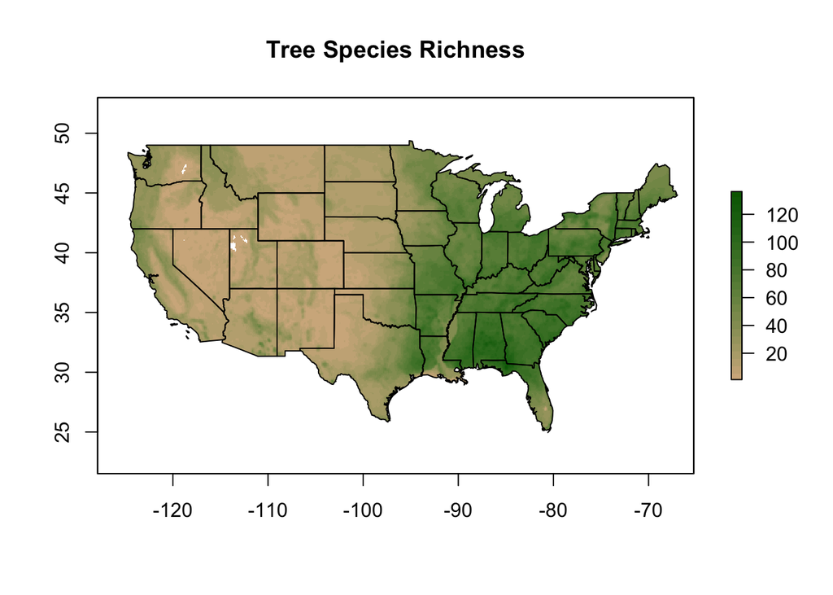

```r
states <- crop(states, extent(temp))
plot(Trees, col=TanGreen(25), main="Tree Species Richness")
plot(states, add=TRUE)
```

## Part 2: Global Spatial Regression Analysis

We could perform the spatial regression analysis on every single cell in the rasters, but that would take a long time, so we are going to draw a subsample of points to analyze instead. We’ll subsample about 2.5% of the points using the spsample() function.

```r
set.seed(21) # The seed allows us to choose the same set of random points each time
pts <- spsample(states, n=600, type="hexagonal")
```

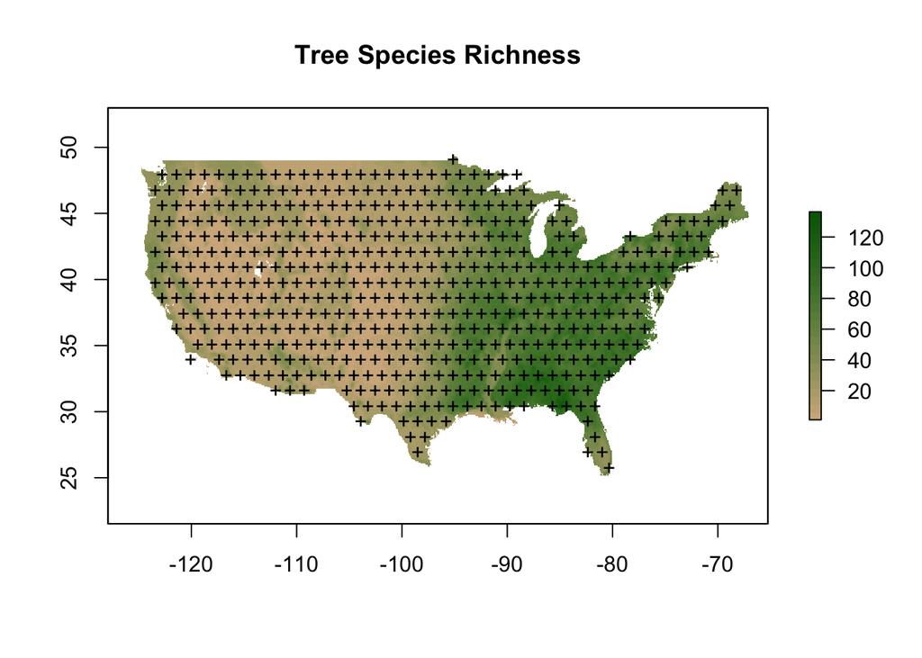

```r
# And plot the results...
plot(Trees, col=TanGreen(25), main="Tree Species Richness")
points(pts, pch='+')
```

### Lab Question 1 (1 pt)

**In the chunk below, create a raster stack with the Trees, Reptiles, temp, and precip rasters. Then extract values for each point using the extract() function, and assign the extracted values to an object named vals.**

extract(x, y) x: a Raster object y: a list of points

```r
# This is basically a freebie; just double-check that this is the right code.
rs <- stack(Trees, Reptiles, temp, precip)
vals <- extract(rs, pts)

# Check that it worked...
vals[1:5, ]
```

```
##         Trees Reptiles temp precip
## [1,] 59.46759 49.38501  241   1367
## [2,] 21.08283 49.53365  225    586
## [3,] 48.01480 48.23573  228   1265
## [4,] 11.22682 42.90447  228   1170
## [5,] 17.95195 47.86488  221    543
```

Now we need to create a data frame from the extracted values…

```r
dframe <- data.frame(lon = pts@coords[,1], lat = pts@coords[,2], TreeSpecies = vals[,"Trees"], ReptileSpecies = vals[,"Reptiles"], temperature = vals[,"temp"], precipitation = vals[,"precip"])
dframe[1:10,]
```

```
##           lon      lat TreeSpecies ReptileSpecies temperature precipitation
## 1   -80.30901 25.79108    59.46759       49.38501         241          1367
## 2   -98.49686 26.95783    21.08283       49.53365         225           586
## 3   -82.32988 26.95783    48.01480       48.23573         228          1265
## 4   -80.98263 26.95783    11.22682       42.90447         228          1170
## 5   -99.17049 28.12458    17.95195       47.86488         221           543
## 6   -97.82324 28.12458    22.39311       57.09953         218           767
## 7   -81.65625 28.12458    53.95510       53.43256         222          1222
## 8  -103.88586 29.29133    16.33913       56.47482         206           277
## 9   -99.84411 29.29133    27.36358       54.07272         202           616
## 10  -98.49686 29.29133    38.66791       63.48143         210           664
```

We can use the attach() function to allow us to call each variable in the data frame by name (as opposed to having to index its column out of the data frame)…

```r
attach(dframe)
TreeSpecies[1:10] # This will give us the extracted values for the TreeSpecies variable.
```

```
##  [1] 59.46759 21.08283 48.01480 11.22682 17.95195 22.39311 53.95510 16.33913
##  [9] 27.36358 38.66791
```

Now, let’s create a simple linear regression model to examine the relationship between Tree species richness, temperature, and precipitation. The lm() function fits a linear model to the variables in the equation we provide. This equation takes the form: y ~ x1 + x2 … where y is the response variable, and x1, x2, etc., are the predictor variables.

```r
trees.model <- lm(TreeSpecies ~ temperature + precipitation)
summary(trees.model)
```

```
##
## Call:
## lm(formula = TreeSpecies ~ temperature + precipitation)
##
## Residuals:
##     Min      1Q  Median      3Q     Max
## -95.572  -8.112  -0.202   9.171  37.388
##
## Coefficients:
##                 Estimate Std. Error t value Pr(>|t|)
## (Intercept)   -11.312692   1.850632  -6.113 1.96e-09 ***
## temperature     0.023270   0.014150   1.645    0.101
## precipitation   0.061374   0.001827  33.601  < 2e-16 ***
## ---
## Signif. codes:  0 '***' 0.001 '**' 0.01 '*' 0.05 '.' 0.1 ' ' 1
##
## Residual standard error: 16.01 on 506 degrees of freedom
## Multiple R-squared:  0.7156, Adjusted R-squared:  0.7144
## F-statistic: 636.5 on 2 and 506 DF,  p-value: < 2.2e-16
```

From the output, you will see a table with the estimated regression coefficients (Estimate), the standard error for those estimates (Std. Error) and the p-value for each predictor variable, PR(>|t|). Below that, you will see the R-squared value fo the model, which is an estimate of the model fit, and the p-value for the whole regression model.

### Lab Question 2 (1 pt)

**Is this linear regression model a significant fit to the data? Which predictor variables contribute significantly to the model?** > Yes this linear regression model is a significant fit to the data (p < 2.2 x 10^-16). Precipitation is a significant contributor to the model (p < 2 x 10^-16)

Remember that the global regression model we just created fits a single equation to the entire dataset. This means that it assumes the relationship between tree species richness, temperature, and precipitation is the same everywhere on the landscape. To see if this is a reasonable assumption, we can map the residuals of the model to examine any geographic trends. The spplot() function in the sp package is one way to plot spatial data with attributes.

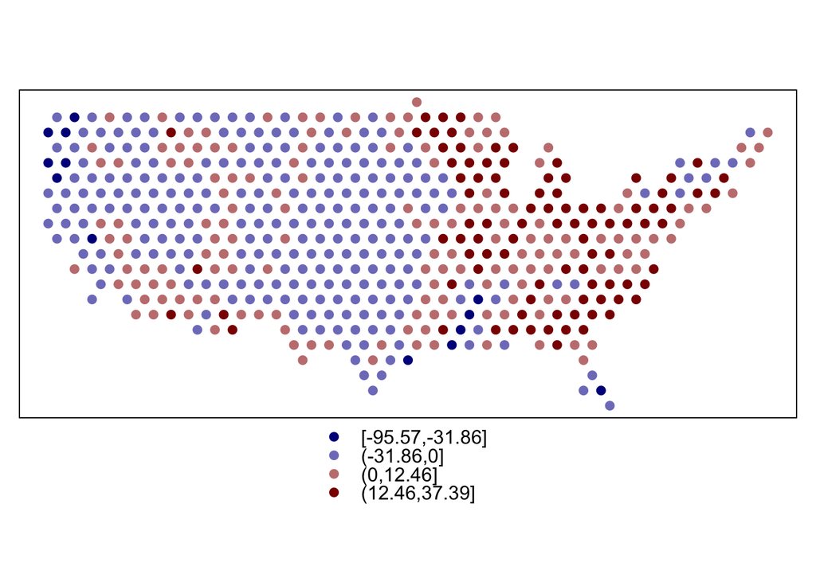

```r
resids <- residuals(trees.model)
breaks <- c(min(resids), min(resids)/3, 0, max(resids)/3, max(resids))
map.resids <- SpatialPointsDataFrame(data=data.frame(resids), coords=cbind(lon,lat))
spplot(map.resids, cuts=breaks, col.regions=BlueRed(5), cex=1)
```

```r
# Construct IDW matrix
geoMat<-pointDistance(pts,longlat=TRUE) # pointDistance calculates pairwise geographic distances
geoMat[upper.tri(geoMat)] <- geoMat[lower.tri(geoMat)] # store these distances in a symmetrical matrix
spdata.IDW <- 1/geoMat # find the inverse distances
diag(spdata.IDW) <- 0 # fill in the diagonal elements

# Perform a global test of Moran's I on the point observations
Moran.I(TreeSpecies, spdata.IDW)
```

```
## $observed
## [1] 0.1892998
##
## $expected
## [1] -0.001968504
##
## $sd
## [1] 0.001970714
##
## $p.value
## [1] 0
```

### Lab Question 3 (1.5 pts)

**Do we have a significant signal of spatial autocorrelation in our residuals? In what part of the country does the model under-predict tree species richness? i.e. Where does the model suggest there is lower tree species richness than the data points show? Remember that the residuals are the observed values minus the modeled (predicted) values.** > Yes, we have a significant signal of spatial aoutocorrelation because nearby points seem to covary with one another. The model over-predicts tree species richness in the pacific northwest and some regions of the south, and under-predicts tree species richness in most of the eastern US.

When we have spatially autocorrelated residuals, we can still conduct a global spatial regression analysis, but we need to account for the spatial structure in our data. To do this, we can use fit statistics of models with different spatial covariance structures to determine the best spatial structure model to use given our data. Basically, this performs the same kind of linear regression analysis but adjusts the point data based on their geographic variation.

```r
dummy <- rep(1, 509)
dframe <- cbind(dframe, dummy) # Add it to the data frame
```

Now we’ll construct the null model, specifying the predictor variable effects (fixed effects) and the spatial covariance effects (random effects). You don’ tneed to worry about this terminology.

```r
null.model <- lme(fixed = TreeSpecies ~ temperature + precipitation, data = dframe, random = ~ 1 | dummy, method = "ML")
summary(null.model)
```

```
## Linear mixed-effects model fit by maximum likelihood
##  Data: dframe
##        AIC     BIC    logLik
##   4274.407 4295.57 -2132.204
##
## Random effects:
##  Formula: ~1 | dummy
##         (Intercept) Residual
## StdDev: 0.000527497  15.9597
##
## Fixed effects: TreeSpecies ~ temperature + precipitation
##                    Value Std.Error  DF  t-value p-value
## (Intercept)   -11.312692 1.8506316 506 -6.11288  0.0000
## temperature     0.023270 0.0141504 506  1.64451  0.1007
## precipitation   0.061374 0.0018265 506 33.60119  0.0000
##  Correlation:
##               (Intr) tmprtr
## temperature   -0.604
## precipitation -0.491 -0.293
##
## Standardized Within-Group Residuals:
##        Min         Q1        Med         Q3        Max
## -5.9883642 -0.5082986 -0.0126754  0.5746499  2.3426741
##
## Number of Observations: 509
## Number of Groups: 1
```

Next, we can run the same model with spatial correlation structures. We can specify such a structure with the correlation option of lme(). We’ll test two kinds of covariance structure, Gaussian (corGaus) and spherical (corSpher).

We can use the update() function to apply each of these to the null model…

```r
gau.sp <- update(null.model, correlation = corGaus(1, form = ~ lat + lon), method = "ML")
writeLines("\nResults for Gaussian spatial correlation:\n")
```

```
##
## Results for Gaussian spatial correlation:
```

```r
summary(gau.sp)
```

```
## Linear mixed-effects model fit by maximum likelihood
##  Data: dframe
##        AIC      BIC    logLik
##   3942.332 3967.727 -1965.166
##
## Random effects:
##  Formula: ~1 | dummy
##         (Intercept) Residual
## StdDev:  0.00107749 15.42312
##
## Correlation Structure: Gaussian spatial correlation
##  Formula: ~lat + lon | dummy
##  Parameter estimate(s):
##    range
## 1.497607
## Fixed effects: TreeSpecies ~ temperature + precipitation
##                  Value Std.Error  DF   t-value p-value
## (Intercept)   4.523292 3.0839273 506  1.466731  0.1431
## temperature   0.048755 0.0182489 506  2.671661  0.0078
## precipitation 0.037056 0.0022658 506 16.354036  0.0000
##  Correlation:
##               (Intr) tmprtr
## temperature   -0.708
## precipitation -0.631  0.112
##
## Standardized Within-Group Residuals:
##        Min         Q1        Med         Q3        Max
## -3.8101843 -0.9293626 -0.3982992  0.9901882  3.1776089
##
## Number of Observations: 509
## Number of Groups: 1
```

```r
sph.sp <- update(null.model, correlation = corSpher(1, form = ~ lat + lon), method = "ML")
```

```r
writeLines("\nResults for spherical spatial correlation:\n")
```

```
##
## Results for spherical spatial correlation:
```

```r
summary(sph.sp)
```

```
## Linear mixed-effects model fit by maximum likelihood
##  Data: dframe
##        AIC      BIC    logLik
##   3654.824 3680.219 -1821.412
##
## Random effects:
##  Formula: ~1 | dummy
##         (Intercept) Residual
## StdDev: 0.006160497 24.22384
##
## Correlation Structure: Spherical spatial correlation
##  Formula: ~lat + lon | dummy
##  Parameter estimate(s):
##   range
## 17.5457
## Fixed effects: TreeSpecies ~ temperature + precipitation
##                  Value Std.Error  DF   t-value p-value
## (Intercept)   38.45730  8.805036 506  4.367648   0e+00
## temperature   -0.07554  0.022161 506 -3.408572   7e-04
## precipitation  0.01187  0.002610 506  4.546674   0e+00
##  Correlation:
##               (Intr) tmprtr
## temperature   -0.43
## precipitation -0.41   0.52
##
## Standardized Within-Group Residuals:
##        Min         Q1        Med         Q3        Max
## -1.5666098 -1.0415174 -0.5084767  0.8821277  3.0861235
##
## Number of Observations: 509
## Number of Groups: 1
```

## Part 3: Geographically Weighted Regression for Tree Species Richness

Correcting for the spatial structure in our data allows us to fit a global spatial regression model, and we can use that to answer questions about the relationship between our modeled variables at the level of the whole study area. However, we may also be interested in seeing how the relationships between the variables in our dataset vary across space, and for this we can perform GWR.

Our goal here is to fit local regressions to TreeSpecies as a function of temperature and precipitation. First, we will calibrate the bandwidth of the kernel that will be used to capture the points for each regression using the gwr.sel() function in the spgwr package (this may take a little while). The bandwidth describes how wide the kernel is - a wide bandwidth will capture more points but weight all of them less.

gwr.sel(formula, data = list(), coords, adapt = FALSE, gweight = gwr.Gauss, …) formula: regression model formula as in glm data: model data frame as in glm, or may be a SpatialPointsDataFrame or SpatialPolygonsDataFrame object as defined in package sp coords: matrix of coordinates of points representing the spatial positions of the observations adapt: either TRUE - find the proportion between 0 and 1 of observations to include in weighting scheme (k-nearest neighbours), or FALSE - find global bandwidth gweight: geographical weighting function, at present gwr.Gauss() default, or gwr.gauss(), the previous default or gwr.bisquare()

Use gwr.sel() to set the kernel bandwidth for the GWR…

```r
gwr.formula <- formula(TreeSpecies ~ temperature + precipitation)
GWRbandwidth <- gwr.sel(gwr.formula, data = dframe, coords = cbind(lon,lat), adapt = TRUE)
```

```
## Adaptive q: 0.381966 CV score: 87395.6
## Adaptive q: 0.618034 CV score: 104593.2
## Adaptive q: 0.236068 CV score: 72016.86
## Adaptive q: 0.145898 CV score: 61252.98
## Adaptive q: 0.09016994 CV score: 52647.07
## Adaptive q: 0.05572809 CV score: 46891.17
## Adaptive q: 0.03444185 CV score: 42767.61
## Adaptive q: 0.02128624 CV score: 39338.33
## Adaptive q: 0.01315562 CV score: 36311.2
## Adaptive q: 0.008130619 CV score: 31483.95
## Adaptive q: 0.005024999 CV score: 31168.09
## Adaptive q: 0.006096446 CV score: 31107.07
## Adaptive q: 0.005925816 CV score: 31131.29
## Adaptive q: 0.006873431 CV score: 31069.89
## Adaptive q: 0.006725977 CV score: 31059.1
## Adaptive q: 0.006609378 CV score: 31058.1
## Adaptive q: 0.006568688 CV score: 31059.13
## Adaptive q: 0.006650069 CV score: 31057.76
## Adaptive q: 0.006650069 CV score: 31057.76
```

```r
GWRbandwidth
```

```
## [1] 0.006650069
```

Now that we have the bandwidth we can fit the GWR model using the gwr() function in the spgwr package.

gwr(formula, data = list(), coords, bandwidth, adapt = NULL, longlat = NULL) formula: regression model formula as in glm data: model data frame as in glm, or may be a SpatialPointsDataFrame or SpatialPolygonsDataFrame object coords: matrix of coordinates of points representing the spatial positions of the observations adapt: either NULL (default) or a proportion between 0 and 1 of observations to include in weighting scheme (k-nearest neighbours) longlat: TRUE if point coordinates are longitude-latitude decimal degrees, in which case distances are measured in kilometers; if x is a SpatialPoints object, the value is se.fit if TRUE, return local coefficient standard errors

```r
gwr.model = gwr(gwr.formula, data = dframe, coords = cbind(lon,lat), adapt = GWRbandwidth, longlat = TRUE)
gwr.model
```

```
## Call:
## gwr(formula = gwr.formula, data = dframe, coords = cbind(lon,
##     lat), adapt = GWRbandwidth, longlat = TRUE)
## Kernel function: gwr.Gauss
## Adaptive quantile: 0.006650069 (about 3 of 509 data points)
## Summary of GWR coefficient estimates at data points:
##                      Min.     1st Qu.      Median     3rd Qu.        Max.
## X.Intercept.  -108.523802  -10.701431    1.591611   20.505658  268.568163
## temperature     -1.504615   -0.115640   -0.027521    0.085598    0.786045
## precipitation   -0.050602    0.021436    0.035411    0.054136    0.241296
##                 Global
## X.Intercept.  -11.3127
## temperature     0.0233
## precipitation   0.0614
```

Now we can look at the coefficients for each of the explanatory variables for each point in our dataset and add them to our original dataframe…

```r
results <- as.data.frame(gwr.model$SDF)
dframe$coef.temp <- results$temperature
dframe$coef.precip <- results$precipitation
dframe[1:10,]
```

```
##           lon      lat TreeSpecies ReptileSpecies temperature precipitation
## 1   -80.30901 25.79108    59.46759       49.38501         241          1367
## 2   -98.49686 26.95783    21.08283       49.53365         225           586
## 3   -82.32988 26.95783    48.01480       48.23573         228          1265
## 4   -80.98263 26.95783    11.22682       42.90447         228          1170
## 5   -99.17049 28.12458    17.95195       47.86488         221           543
## 6   -97.82324 28.12458    22.39311       57.09953         218           767
## 7   -81.65625 28.12458    53.95510       53.43256         222          1222
## 8  -103.88586 29.29133    16.33913       56.47482         206           277
## 9   -99.84411 29.29133    27.36358       54.07272         202           616
## 10  -98.49686 29.29133    38.66791       63.48143         210           664
##    dummy   coef.temp coef.precip
## 1      1 -0.73729924  0.13901641
## 2      1 -0.05671018  0.04905340
## 3      1 -0.88288581  0.15791181
## 4      1 -0.93640225  0.24129606
## 5      1 -0.11563975  0.03441031
## 6      1 -0.32849931  0.02238299
## 7      1 -1.03440923  0.16971151
## 8      1  0.07675606  0.02670694
## 9      1  0.11988173  0.04576031
## 10     1  0.01050449  0.04358979
```

Of course, it’s easier to visualize how the coefficients vary if we plot them in space.

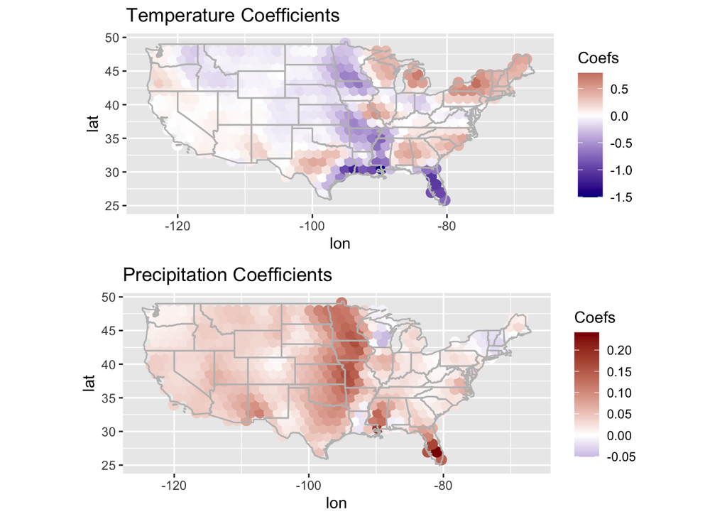

```r
gwr.temp <- ggplot(dframe, aes(x=lon,y=lat)) + geom_point(aes(color=coef.temp), size = 3) + scale_colour_gradient2(low = "darkblue", high = "darkred", mid="white", na.value = "grey50", guide = "colourbar", guide_legend(title="Coefs")) + ggtitle("Temperature Coefficients")
gwr.precip <- ggplot(dframe, aes(x=lon,y=lat)) + geom_point(aes(color=coef.precip), size = 3) + scale_colour_gradient2(low = "darkblue", high = "darkred", mid="white", na.value = "grey50", guide = "colourbar", guide_legend(title="Coefs"))+ ggtitle("Precipitation Coefficients")
dframe <- dframe[, -6]
grid.arrange(gwr.temp + geom_path(data=states, aes(long, lat, group=group), colour="grey") + coord_equal(),
             gwr.precip + geom_path(data=states, aes(long, lat, group=group), colour="grey") + coord_equal(), nrow=2)
```

### Lab Question 5 (1.5 pts)

**What variable(s) contribute to tree species richness in California? Is/Are the effect(s) on tree species richness positive or negative?** > Precipitation contributes to tree species ricness in California. The effects on tree species richness is positive (i.e. more precipitation = greater species richness)

## Part 3: Geographically Weighted Regression for Reptile Species Richness

Finally, let’s create a GWR model for reptile species richness using temperature, precipitation, and tree species richness as predictor variables.

### Lab Question 6 (1 pt)

**In the code chunk below, fill in the formula that we need to use to construct the GWR model that has reptile species richness as the response variable and that has temperature, precipitation, and tree species richness as predictor variables.**

```r
reptile.formula <- formula(ReptileSpecies ~ temperature + precipitation + TreeSpecies)
```

And then run the GWR analysis…

```r
# No need to change anything in this code chunk.
reptile.bdw <- gwr.sel(reptile.formula, data = dframe, coords = cbind(lon,lat), adapt = TRUE)
```

```
## Adaptive q: 0.381966 CV score: 20013.65
## Adaptive q: 0.618034 CV score: 22100.45
## Adaptive q: 0.236068 CV score: 17515.53
## Adaptive q: 0.145898 CV score: 14793.98
## Adaptive q: 0.09016994 CV score: 12405.88
## Adaptive q: 0.05572809 CV score: 10349.37
## Adaptive q: 0.03444185 CV score: 8771.25
## Adaptive q: 0.02128624 CV score: 7565.302
## Adaptive q: 0.01315562 CV score: 6971.115
## Adaptive q: 0.008130619 CV score: 6344.428
## Adaptive q: 0.005024999 CV score: 6181.264
## Adaptive q: 0.003618604 CV score: 6154.327
## Adaptive q: 0.003027436 CV score: 6144.544
## Adaptive q: 0.001871058 CV score: 6217.744
## Adaptive q: 0.002585739 CV score: 6152.509
## Adaptive q: 0.003075899 CV score: 6144.32
## Adaptive q: 0.003135686 CV score: 6144.302
## Adaptive q: 0.003320144 CV score: 6146.098
## Adaptive q: 0.003176376 CV score: 6144.457
## Adaptive q: 0.003135686 CV score: 6144.302
```

```r
reptile.model = gwr(reptile.formula, data = dframe, coords = cbind(lon,lat), adapt = reptile.bdw, longlat = TRUE)
rept.results <- as.data.frame(reptile.model$SDF)
dframe$rept.temp <- rept.results$temperature
dframe$rept.precip <- rept.results$precipitation
dframe$rept.trees <- rept.results$TreeSpecies
```

And plot the results (temperature first)…

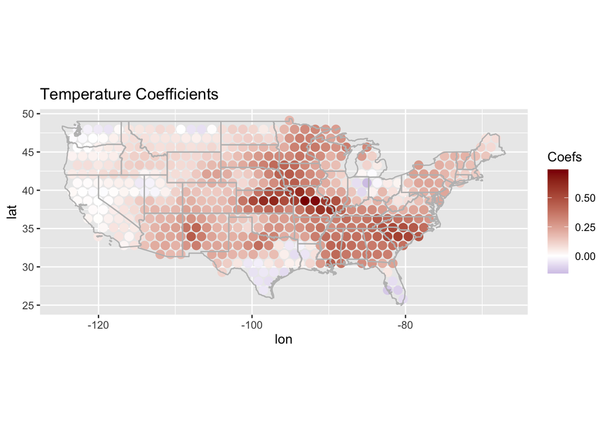

```r
# No need to change anything in this code chunk.
rept.temp <- ggplot(dframe, aes(x=lon,y=lat)) + geom_point(aes(color=rept.temp), size = 3) + scale_colour_gradient2(low = "darkblue", high = "darkred", mid="white", na.value = "grey50", guide = "colourbar", guide_legend(title="Coefs")) + ggtitle("Temperature Coefficients")
rept.precip <- ggplot(dframe, aes(x=lon,y=lat)) + geom_point(aes(color=rept.precip), size = 3) + scale_colour_gradient2(low = "darkblue", high = "darkred", mid="white", na.value = "grey50", guide = "colourbar", guide_legend(title="Coefs"))+ ggtitle("Precipitation Coefficients")
rept.trees <- ggplot(dframe, aes(x=lon,y=lat)) + geom_point(aes(color=rept.trees), size = 3) + scale_colour_gradient2(low = "darkblue", high = "darkred", mid="white", na.value = "grey50", guide = "colourbar", guide_legend(title="Coefs"))+ ggtitle("Tree Richness Coefficients")

rept.temp + geom_path(data = states, aes(long, lat, group=group), colour="grey") + coord_equal()
```

Then precipitation…

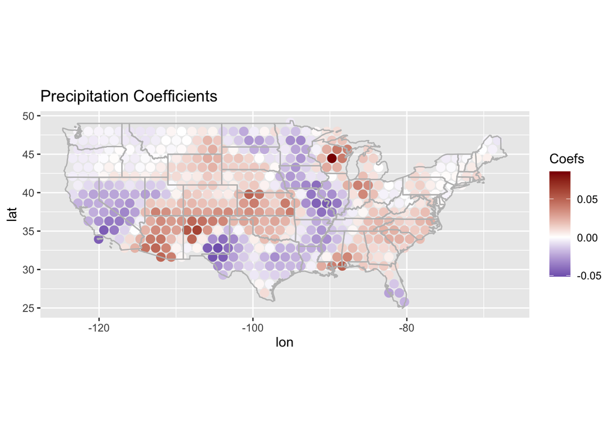

```r
rept.precip + geom_path(data = states, aes(long, lat, group=group), colour="grey") + coord_equal()
```

And tree species richness…

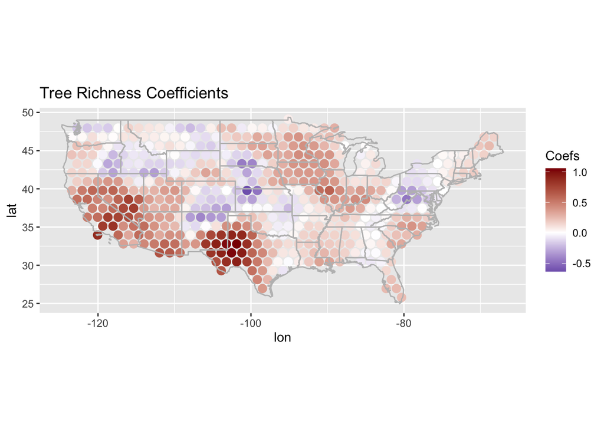

```r
rept.trees + geom_path(data = states, aes(long, lat, group=group), colour="grey") + coord_equal()
```

### Lab Question 7 (2 pts)

**Based on the points closest to the Bay Area, what effect do temperature, precipitation, and tree species richness have on reptile species richness around the Bay Area? Are the effects of these predictor variables positive or negative in the Bay Area? What about in Arizona - which variables have positive or negative effects on reptile species richness there?** > Around the Bay Area in California, temperature has a little to no effect on reptile species richness, precipitation has a negative effect on reptile species richness, and tree species richness has a positive effect on reptile species richness. In Arizona, temperature, precipitation, and tree species richness all have a positive effect on reptile species richness.